# randomForest를 사용한 iris 분류

Jun

2020-01-20

## 1. 탐색적 데이터 분석 (EDA)

분석에 앞서 가장 먼저 해야할 것은 데이터의 구조를 파악하는 것이다.  
여기서 데이터는 tranining_set을 기준으로 파악할 것이며, 먼저 ’Species’를 분류하는데 어떤 데이터가 필요한지 확인해보자.

### 1) 패키지 설치 / library 활성화

```r
library(kernlab)
library(nnet)
library(rpart)
library(randomForest)
library(dplyr)
library(stats)
library(caret)
library(DT)
library(class)
library(ggvis)
```

### 2) 데이터 시각화

시각화를 통해 ‘Petal.Length’ 와 ‘Petal.Width’ 가 선형성 구조를 보이고 있으므로 이를 통해 분석에 적합성을 가지고 있다는 사실을 알 수 있다.

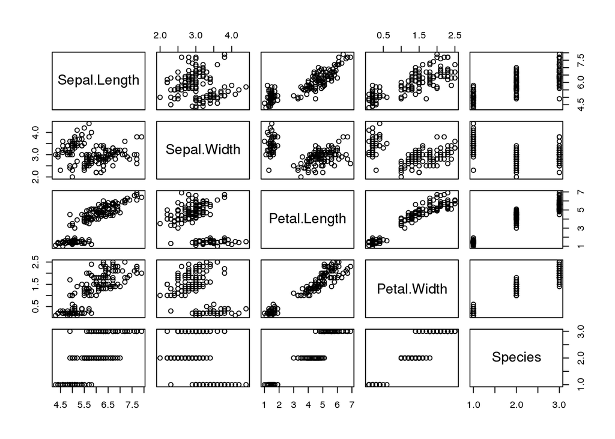

```r
plot(iris)
```

그래프를 통해 보는 바와 같이 ’Setosa’의 데이터가 가장 정확하게 분류되는 것을 확인할 수 있다.

```r
iris %>% ggvis(~Petal.Length, ~Petal.Width, fill = ~factor(Species)) %>%
  layer_points()
```

[output not shown]

### 3) 데이터 구조 파악

str() 함수를 통해 iris 데이터의 구조를 확인해보자.

```r
str(iris)
```

```
## 'data.frame':    150 obs. of  5 variables:
##  $ Sepal.Length: num  5.1 4.9 4.7 4.6 5 5.4 4.6 5 4.4 4.9 ...
##  $ Sepal.Width : num  3.5 3 3.2 3.1 3.6 3.9 3.4 3.4 2.9 3.1 ...
##  $ Petal.Length: num  1.4 1.4 1.3 1.5 1.4 1.7 1.4 1.5 1.4 1.5 ...
##  $ Petal.Width : num  0.2 0.2 0.2 0.2 0.2 0.4 0.3 0.2 0.2 0.1 ...
##  $ Species     : Factor w/ 3 levels "setosa","versicolor",..: 1 1 1 1 1 1 1 1 1 1 ...
```

### 4) 통계적 수치 파악

iris 데이터의 통계적 수치를 확인해보자.

```r
summary(iris)
```

```
##   Sepal.Length    Sepal.Width     Petal.Length    Petal.Width
##  Min.   :4.300   Min.   :2.000   Min.   :1.000   Min.   :0.100
##  1st Qu.:5.100   1st Qu.:2.800   1st Qu.:1.600   1st Qu.:0.300
##  Median :5.800   Median :3.000   Median :4.350   Median :1.300
##  Mean   :5.843   Mean   :3.057   Mean   :3.758   Mean   :1.199
##  3rd Qu.:6.400   3rd Qu.:3.300   3rd Qu.:5.100   3rd Qu.:1.800
##  Max.   :7.900   Max.   :4.400   Max.   :6.900   Max.   :2.500
##        Species
##  setosa    :50
##  versicolor:50
##  virginica :50
##
##
##
```

### 5) 결측치 확인

결측치 유무를 확인해보자.

```r
sum(is.na(iris))
```

```
## [1] 0
```

## 2. 데이터 처리

```r
# 데이터 할당
df <- iris

# seed값 설정
set.seed(919)

# training / test sampling
training_sampling <- sort(sample(1:nrow(df), nrow(df) * 0.7 ))
test_sampling <- setdiff(1: nrow(df), training_sampling)

# training / test set
training_set <- df[training_sampling,]
test_set <- df [test_sampling,]
```

## 3. 머신러닝 모델 생성

```r
multi_logit_m <- multinom(Species ~ Petal.Length + Petal.Width, data = training_set)
multi_logit_p <- predict(multi_logit_m, newdata = test_set, type = "class")
```

2. Decision tree를 통한 분류  
   의사결정 나무 기법을 사용한 iris 분류를 해보자. 의사결정 나무란, 데이터를 나무가 가지 치듯이 차례차례 분류하여 최종적으로 분류하는 모델을 의미한다. rpart패키지 불러와 rpart 함수를 사용하여 Decision tree를 생성해보자.  
   https://liujingjun.tistory.com/27?category=828394

```r
rpart_m <- rpart(Species ~ Petal.Length + Petal.Width, data = training_set)

rpart_p <- predict(rpart_m, newdata = test_set, type = "class")
```

3. Random Forest를 통한 분류  
   앙상블 기법의 일종으로 여러가지 기술을 가진 의사결정 나무들이 모여있는 형태라고 볼 수 있다. randomForest패키지의 randomForest함수를 사용하여 Random Forest 모델을 만들어 보자.  
   https://liujingjun.tistory.com/27?category=828394

```r
rf_m <- randomForest(Species ~ Petal.Length + Petal.Width, data = training_set)
rf_p <- predict(rf_m, newdata = test_set, type = "class")
```

4. Neural Network을 통한 분류  
   이번엔 Neural Network을 통해 분류를 해볼 것이다. neural network란 인간의 뇌를 본따서 만든 모델이다. 뉴런을 흉내내서 만들었으며 입력층, 은닉층, 출력층으로 구분되어 있다. 은닉층에서 입력값이 조합되기 때문에 비선형적인 문제를 해결할 수 있다.

```r
nnet_m <- nnet(Species ~ Petal.Length + Petal.Width, data = training_set, size = 3)
nnet_p <- predict(nnet_m, newdata = test_set, type ="class")
```

5. Support Vector Machine을 통한 분류  
   이번엔 Support Vector Machine 을 통해 분류를 해볼 것이다. SVM(Support Vector Machine)이란 데이터 상에 있는 각점들의 거리를 분석해 가장 먼 거리에 있는 점들을 기준으로 support vector를 형성하여 두개의 support vector 중간에 초평면을 만들어 분류를 하는 방법이다. 쉽게말하면 두점 사이의 거리가 최대가 되는 지점을 찾는 것이다.

```r
svm_m <- ksvm(Species ~ Petal.Length + Petal.Width, data = training_set)
svm_p <- predict(svm_m, newdata = test_set)
```

6. K-Nearest Neighbor을 통한 분류  
   이번엔 KNN으로 분류를 해보자. KNN이란 K-Nearest Neighbor의 점들에 주어진 가장 근접해있는 K근접이웃을 알아내는 과정이다. 자세한 내용은 기술블로그를 참고하도록 하자.

```r
normalizer <- function(x) {
  return_value <- (x - min(x)) / (max(x) - min(x))
return(return_value)
}
```

```r
normal_iris <- sapply(iris[,1:4], normalizer) %>%
  as.data.frame()

# 데이터 생성
df <- cbind(normal_iris, "Species" = iris[,5])

# training / test sampling
training_sampling <- sort(sample(1:nrow(df), nrow(df)* 0.7))
test_sampling <- setdiff(1:nrow(df), training_sampling)

# training_set, test_set
training_set <- df[training_sampling,]
test_set <- df[test_sampling,]

training_set_unlable <- training_set[,1:4]
training_set_lable <- training_set[,5]

test_set_unlable <- test_set[,1:4]
test_set_lable <- test_set[,5]

knn_p <- knn(train = training_set_unlable, test = test_set_unlable, cl = training_set_lable, k =3)
```

## 4. 모델 평가

```r
model_list <- cbind(
  as.character(multi_logit_p),
  as.character(rpart_p),
  as.character(rf_p),
  as.character(nnet_p),
  as.character(svm_p),
  as.character(knn_p) %>%
  as.data.frame()
)

# str(model_list)

total_model_accuracy <- data.frame()
for (model in model_list[, 1:ncol(model_list)]) {
  model_cm <- confusionMatrix(model, test_set$Species)
  model_cm_class <- model_cm$byClass %>% as.data.frame()
  model_accuracy <- model_cm_class$'Balanced Accuracy'
  total_model_accuracy <- rbind(total_model_accuracy, model_accuracy)

}

colnames(total_model_accuracy) <- levels(test_set$Species)
rownames(total_model_accuracy) <- c("Logistic Regression", "Decision Tree",
                                    "Random Forest", "Neural Network", "Support Vector Machine","KNN")
```

## 모델의 정확도 비교 테이블

예측값, 실측값의 비교를 위해 각 모델별 분류에 대한 정확도 비교테이블이다.

```r
datatable(total_model_accuracy)
```

|  | setosa | versicolor | virginica |
| --- | --- | --- | --- |
| Logistic Regression | 0.966666666666667 | 0.833333333333333 | 0.9 |
| Decision Tree | 0.966666666666667 | 0.85 | 0.883333333333333 |
| Random Forest | 0.966666666666667 | 0.833333333333333 | 0.9 |
| Neural Network | 0.966666666666667 | 0.8 | 0.883333333333333 |
| Support Vector Machine | 0.933333333333333 | 0.85 | 0.866666666666667 |
| KNN | 1 | 0.916666666666667 | 0.933333333333333 |

결과  
이렇게 6가지의 모델로 iris 데이터를 분류해 보았다. 6개의 모델 모두 대체적으로 높은 수준의 예측률을 보여주었다. 그러나 당장 위의 수치만으로는 어떤 모델이 더 좋다라는 것을 판단하기에는 무리가 있다. iris데이터는 분류가 잘되는 데이터 였지만, 세상에는 iris와 같이 분류가 잘 되는 데이터만이 있는 것이 아니다. 특히 인간의 생명과 연결된 의료분야에서 많은 데이터 분석이 진행중인데 이러한 분야에서는 데이터 분석가의 도메인 지식과 역량에 따라 데이터 분석을 함에 있어서 가장 적합한 모델을 선정하여 분석해야한다. 그러기 위해서는 다양한 모델들의 개념과 특성을 알아야하며 주어진 데이터를 분석하는대에 있어서 어떠한 모델을 사용하고 또한 그 속에서 사용되는 여러가지 옵션들을 잘 다룰 수 있는 역량을 갖추어야 한다고 생각한다.